# Ayush_Kumar_08_Oct_2023

You have been given the role of a business analyst for an E-Commerce company and have been asked to prepare a basic report on the data. Follow the steps below for preparation of the report.

Before you start analysing the data, it is always a good practice to see the size of the data, its features and feature types. If the data set is big, it is not possible to print out all the records. </font>

#### Note: Use the markdown feature of Python to explain your answer.

## Load the necessary libraries. Import and load the dataset with a name ECom_Data .

```python
import numpy as np
import pandas as pd
import matplotlib.pyplot as plt
import seaborn as sns
pd.options.display.max_rows = 10
```

```python
# Get the Data

df=pd.read_csv("E-Commerce.csv")
df.head(5)
```

|  | Customer_uniq_id | Region | Order_Date | Expected_Delivery_Date | Delivered_Date | product_name | product_main_category | product_subcategory | product_category_filter | product_category_subfilter | product_unique ID | retail_price | discounted_price | product_rating | Brand | product_specifications | description |
| --- | --- | --- | --- | --- | --- | --- | --- | --- | --- | --- | --- | --- | --- | --- | --- | --- | --- |
| 0 | e71017e224688489edfe856f2308806d | East | 24-10-2021 | 25-10-2021 | 25-10-2021 | Indcrown Net Embroidered Semi-stitched Lehenga... | Clothing | Women's Clothing | Ethnic Wear | Fabric | FABEJX2NHNKCYHKA | 999 | 699 | 4.0 | INDCROWN | {"product_specification"=>[{"key"=>"Fabric", "... | Key Features of Indcrown Net Embroidered Semi-... |
| 1 | 6286847ee2da18f587503db49511c539 | East | 24-10-2021 | 25-10-2021 | 25-10-2021 | Shopmania Music Band A5 Notebook Spiral Bound | Pens & Stationery | Diaries & Notebooks | Notebooks | Designer | DIAEJ6Z8BEDTGGYY | 499 | 275 | 1.0 | SHOPMANIA | {"product_specification"=>[{"key"=>"Ruling", "... | Specifications of Shopmania Music Band A5 Note... |
| 2 | 0686fec9b70e5039583a38119ca0c835 | West | 24-10-2021 | 25-10-2021 | 25-10-2021 | Shopmania Music Band A5 Notebook Spiral Bound | Pens & Stationery | Diaries & Notebooks | Notebooks | Designer | DIAEJ6Z8KQFWDEGH | 499 | 275 | 2.0 | SHOPMANIA | {"product_specification"=>[{"key"=>"Ruling", "... | Specifications of Shopmania Music Band A5 Note... |
| 3 | ea2406dc597bee2abb6b867fa668501f | West | 24-10-2021 | 25-10-2021 | 25-10-2021 | Tiara Diaries 2016-2017 Designer LA Kaarta "TA... | Pens & Stationery | Diaries & Notebooks | Notebooks | Designer | DIAEJ8FGHZ3K86JU | 1000 | 837 | 3.0 | TIARA DIARIES | {"product_specification"=>[{"key"=>"Ruling", "... | Specifications of Tiara Diaries 2016-2017 Desi... |
| 4 | 5935ed077915347dc695744df68c565c | East | 03-09-2021 | 04-09-2021 | 04-09-2021 | KAJCI Embroidered Women's Waistcoat | Clothing | Women's Clothing | Formal Wear | Waistcoats | WSCEG2FYDYFDSVZ6 | 1200 | 699 | 5.0 | KAJCI | {"product_specification"=>[{"key"=>"Pattern", ... | Specifications of KAJCI Embroidered Women's Wa... |

```python
df.shape
```

```
(8906, 17)
```

```python
df.info()
```

```
<class 'pandas.core.frame.DataFrame'>
RangeIndex: 8906 entries, 0 to 8905
Data columns (total 17 columns):
 #   Column                      Non-Null Count  Dtype
---  ------                      --------------  -----
 0   Customer_uniq_id            8906 non-null   object
 1   Region                      8906 non-null   object
 2   Order_Date                  8906 non-null   object
 3   Expected_Delivery_Date      8906 non-null   object
 4   Delivered_Date              8906 non-null   object
 5   product_name                8906 non-null   object
 6   product_main_category       8906 non-null   object
 7   product_subcategory         8906 non-null   object
 8   product_category_filter     8906 non-null   object
 9   product_category_subfilter  8906 non-null   object
 10  product_unique ID           8906 non-null   object
 11  retail_price                8906 non-null   int64
 12  discounted_price            8906 non-null   int64
 13  product_rating              8906 non-null   float64
 14  Brand                       8906 non-null   object
 15  product_specifications      8906 non-null   object
 16  description                 8906 non-null   object
dtypes: float64(1), int64(2), object(14)
memory usage: 1.2+ MB
```

```python
df.describe()
```

|  | retail_price | discounted_price | product_rating |
| --- | --- | --- | --- |
| count | 8906.000000 | 8906.000000 | 8906.000000 |
| mean | 1969.965304 | 1093.698518 | 3.066596 |
| std | 3341.314408 | 2433.776099 | 1.413313 |
| min | 115.000000 | 109.000000 | 1.000000 |
| 25% | 730.000000 | 350.000000 | 2.000000 |
| 50% | 1195.000000 | 599.000000 | 3.000000 |
| 75% | 2199.000000 | 1199.000000 | 4.000000 |
| max | 116292.000000 | 116292.000000 | 5.000000 |

We have read the data and stored the data in "df" variable

## Q 1. To get familiar with the data

## a) Print out the first 10 and the last 10 records of the data. (2 marks)

## b) How many rows and columns are present in the dataset? Use any two different methods to extract this information. (2 + 2 + 2 marks)

## c) How many object data types are there? (1 mark)

## d) Is there any Boolean data type? (1 mark)

#### Note: Use the markdown feature of Python to explain your answer.

### Ans 1 a) - First 10 records

```python
df.head(10)
```

|  | Customer_uniq_id | Region | Order_Date | Expected_Delivery_Date | Delivered_Date | product_name | product_main_category | product_subcategory | product_category_filter | product_category_subfilter | product_unique ID | retail_price | discounted_price | product_rating | Brand | product_specifications | description |
| --- | --- | --- | --- | --- | --- | --- | --- | --- | --- | --- | --- | --- | --- | --- | --- | --- | --- |
| 0 | e71017e224688489edfe856f2308806d | East | 24-10-2021 | 25-10-2021 | 25-10-2021 | Indcrown Net Embroidered Semi-stitched Lehenga... | Clothing | Women's Clothing | Ethnic Wear | Fabric | FABEJX2NHNKCYHKA | 999 | 699 | 4.0 | INDCROWN | {"product_specification"=>[{"key"=>"Fabric", "... | Key Features of Indcrown Net Embroidered Semi-... |
| 1 | 6286847ee2da18f587503db49511c539 | East | 24-10-2021 | 25-10-2021 | 25-10-2021 | Shopmania Music Band A5 Notebook Spiral Bound | Pens & Stationery | Diaries & Notebooks | Notebooks | Designer | DIAEJ6Z8BEDTGGYY | 499 | 275 | 1.0 | SHOPMANIA | {"product_specification"=>[{"key"=>"Ruling", "... | Specifications of Shopmania Music Band A5 Note... |
| 2 | 0686fec9b70e5039583a38119ca0c835 | West | 24-10-2021 | 25-10-2021 | 25-10-2021 | Shopmania Music Band A5 Notebook Spiral Bound | Pens & Stationery | Diaries & Notebooks | Notebooks | Designer | DIAEJ6Z8KQFWDEGH | 499 | 275 | 2.0 | SHOPMANIA | {"product_specification"=>[{"key"=>"Ruling", "... | Specifications of Shopmania Music Band A5 Note... |
| 3 | ea2406dc597bee2abb6b867fa668501f | West | 24-10-2021 | 25-10-2021 | 25-10-2021 | Tiara Diaries 2016-2017 Designer LA Kaarta "TA... | Pens & Stationery | Diaries & Notebooks | Notebooks | Designer | DIAEJ8FGHZ3K86JU | 1000 | 837 | 3.0 | TIARA DIARIES | {"product_specification"=>[{"key"=>"Ruling", "... | Specifications of Tiara Diaries 2016-2017 Desi... |
| 4 | 5935ed077915347dc695744df68c565c | East | 03-09-2021 | 04-09-2021 | 04-09-2021 | KAJCI Embroidered Women's Waistcoat | Clothing | Women's Clothing | Formal Wear | Waistcoats | WSCEG2FYDYFDSVZ6 | 1200 | 699 | 5.0 | KAJCI | {"product_specification"=>[{"key"=>"Pattern", ... | Specifications of KAJCI Embroidered Women's Wa... |
| 5 | 89fcdddaad50084e395d0928a7426afe | East | 03-09-2021 | 04-09-2021 | 04-09-2021 | Packman 8 x 10 inches Security Bags Without PO... | Pens & Stationery | Office Supplies | Packaging Security Bags | Packman Packaging Security Bags | PKBEGBTRKKHU26YQ | 350 | 298 | 4.0 | PACKMAN | {"product_specification"=>[{"key"=>"Bubble Wra... | Key Features of Packman 8 x 10 inches Security... |
| 6 | b9b183aa18d3a721d2ac23e7184525b0 | East | 03-09-2021 | 04-09-2021 | 04-09-2021 | Pick Pocket Embroidered Women's Waistcoat | Clothing | Women's Clothing | Formal Wear | Waistcoats | WSCEFUV4TVWT73ZB | 899 | 899 | 1.0 | PICK POCKET | {"product_specification"=>[{"key"=>"Pattern", ... | Specifications of Pick Pocket Embroidered Wome... |
| 7 | dee64864c0419bec80fbbb94d19bc40d | East | 03-09-2021 | 04-09-2021 | 04-09-2021 | Angelfish Silk Potali Potli | Bags, Wallets & Belts | Bags | Pouches and Potlis | Angelfish Pouches and Potlis | PPSEGFYAGD8FYUXV | 999 | 399 | 4.0 | ANGELFISH | {"product_specification"=>[{"key"=>"Closure", ... | Angelfish Silk Potali Potli (Multicolor) Price... |
| 8 | 595f55f2c1293f07ea9ec9fa2bb39f46 | East | 03-09-2021 | 04-09-2021 | 04-09-2021 | Oye Boy's Dungaree | Clothing | Kids' Clothing | Boys Wear | Dungarees & Jumpsuits | DRPEF2XSFBAP4SUZ | 899 | 764 | 1.0 | OYE | {"product_specification"=>[{"key"=>"Number of ... | Specifications of Oye Boy's Dungaree Top Detai... |
| 9 | 547b6585272473ae006bcfbdb47b6ae0 | West | 26-08-2021 | 27-08-2021 | 27-08-2021 | Nuride Canvas Shoes | Footwear | Women's Footwear | Casual Shoes | Canvas | SHOEGVQCT2ZSGUHY | 1999 | 1349 | 2.0 | NURIDE | {"product_specification"=>[{"key"=>"Occasion",... | Key Features of Nuride Canvas Shoes Material: ... |

### Ans 1 a) - Last 10 records

```python
df.tail(10)
```

|  | Customer_uniq_id | Region | Order_Date | Expected_Delivery_Date | Delivered_Date | product_name | product_main_category | product_subcategory | product_category_filter | product_category_subfilter | product_unique ID | retail_price | discounted_price | product_rating | Brand | product_specifications | description |
| --- | --- | --- | --- | --- | --- | --- | --- | --- | --- | --- | --- | --- | --- | --- | --- | --- | --- |
| 8896 | 4db03bc4ccbe216cf151b2f2b904ba3f | East | 01-12-2020 | 04-12-2020 | 04-12-2020 | Luca Fashion Girls Heels | Footwear | Kids' & Infant Footwear | For Girls | Sandals | SNDEHG3DNVBFGAT5 | 999 | 499 | 4.0 | LUCA FASHION | {"product_specification"=>[{"key"=>"Occasion",... | Key Features of Luca Fashion Girls Heels Occas... |
| 8897 | 4d4d6aeb13fa253499d0dd45a5abd87e | West | 01-12-2020 | 04-12-2020 | 04-12-2020 | Shoetopia Girls Sandals | Footwear | Kids' & Infant Footwear | For Girls | Sandals | SNDEG7DRWSX8HFXZ | 499 | 399 | 4.0 | SHOETOPIA | {"product_specification"=>[{"key"=>"Ideal For"... | Key Features of Shoetopia Girls Sandals Flats ... |
| 8898 | ea19e7ef703293d3f6c799ca9db4642d | West | 01-12-2020 | 04-12-2020 | 04-12-2020 | SMART TRADERS Girls Sandals | Footwear | Kids' & Infant Footwear | For Girls | Sandals | SNDEG7MZHHKZ58D2 | 999 | 499 | 5.0 | SMART TRADERS | {"product_specification"=>[{"key"=>"Ideal For"... | Key Features of SMART TRADERS Girls Sandals Oc... |
| 8899 | 19a53a958992fb575acffb5d41e7ef9e | East | 01-12-2020 | 04-12-2020 | 04-12-2020 | Beanz Girls Flats | Footwear | Kids' & Infant Footwear | For Girls | Sandals | SNDEG7DYVFWHZBC4 | 1299 | 1299 | 3.0 | BEANZ | {"product_specification"=>[{"key"=>"Occasion",... | Key Features of Beanz Girls Flats Occasion: Ca... |
| 8900 | 09abab80c8dfdc6f268e0a6f05a0be11 | North | 01-12-2020 | 04-12-2020 | 04-12-2020 | Nova KT 728S Electric Kettle | Home & Kitchen | Kitchen Appliances | Electric Jug(heater)/Travel Kettles | Nova Electric Jug(heater)/Travel Kettles | EKTDG5C5QSADZZ8J | 3195 | 699 | 3.6 | NOVA | {"product_specification"=>[{"key"=>"Brand", "v... | Specifications of Nova KT 728S Electric Kettle... |
| 8901 | 90d30478255e23621e8929ed15c2f6e4 | South | 01-12-2020 | 04-12-2020 | 04-12-2020 | Sinina Chanderi Embroidered Salwar Suit Dupatt... | Clothing | Women's Clothing | Ethnic Wear | Fabric | FABEGGHHDFMY8BZU | 2980 | 1490 | 3.0 | SININA | {"product_specification"=>[{"key"=>"Fabric", "... | Key Features of Sinina Chanderi Embroidered Sa... |
| 8902 | 20a73e3f41490a73ceeba5f17658db8f | West | 01-12-2020 | 04-12-2020 | 04-12-2020 | Aarushi Fashion Chanderi Embroidered Salwar Su... | Clothing | Women's Clothing | Ethnic Wear | Fabric | FABEG8GFDUWRSNU3 | 2600 | 1300 | 1.0 | AARUSHI FASHION | {"product_specification"=>[{"key"=>"Fabric", "... | Key Features of Aarushi Fashion Chanderi Embro... |
| 8903 | 5c1554cd45f9d538c2c6947dbdd59c75 | East | 01-12-2020 | 04-12-2020 | 04-12-2020 | Ambika Lahenga Embroidered Lehenga, Choli and ... | Clothing | Women's Clothing | Ethnic Wear | Lehenga Cholis | LEHEGGEHYN4G2RPW | 39992 | 24995 | 1.0 | AMBIKA LAHENGA | {"product_specification"=>[{"key"=>"Fabric", "... | Key Features of Ambika Lahenga Embroidered Leh... |
| 8904 | 6b737a4deca1ed0e56c179e66036e994 | West | 01-12-2020 | 04-12-2020 | 04-12-2020 | Sinina Chanderi Embroidered Salwar Suit Dupatt... | Clothing | Women's Clothing | Ethnic Wear | Fabric | FABEGGHHGSVCHGFV | 2000 | 1000 | 3.0 | SININA | {"product_specification"=>[{"key"=>"Fabric", "... | Key Features of Sinina Chanderi Embroidered Sa... |
| 8905 | a5235ac28d3d5487f54025f9d6b57433 | North | 01-12-2020 | 04-12-2020 | 04-12-2020 | Aarushi Fashion Silk Striped Salwar Suit Dupat... | Clothing | Women's Clothing | Ethnic Wear | Fabric | FABEG8GYDAABECZH | 2800 | 1350 | 4.0 | AARUSHI FASHION | {"product_specification"=>[{"key"=>"Fabric", "... | Key Features of Aarushi Fashion Silk Striped S... |

### Ans 1 b)

#### First Method

```python
df.shape

print("The number of rows are", df.shape[0])
print("The number of columns are", df.shape[1])
```

```
The number of rows are 8906
The number of columns are 17
```

#### Second Method

```python
# Here we are using the iloc function to get the data of row number 3 in variable and then calcualting the len of that variable.
a = df.iloc[2]

print("The number of rows are",len(df))
print("The no. of columns are",len(a))
```

```
The number of rows are 8906
The no. of columns are 17
```

#### Third Method

```python
row_count = len(df.axes[0])
columns_count = len(df.axes[1])

print("The number of rows are",row_count)
print("The no. of columns are",columns_count)
```

```
The number of rows are 8906
The no. of columns are 17
```

### Ans 1 c)

```python
df.info()
```

```
<class 'pandas.core.frame.DataFrame'>
RangeIndex: 8906 entries, 0 to 8905
Data columns (total 17 columns):
 #   Column                      Non-Null Count  Dtype
---  ------                      --------------  -----
 0   Customer_uniq_id            8906 non-null   object
 1   Region                      8906 non-null   object
 2   Order_Date                  8906 non-null   object
 3   Expected_Delivery_Date      8906 non-null   object
 4   Delivered_Date              8906 non-null   object
 5   product_name                8906 non-null   object
 6   product_main_category       8906 non-null   object
 7   product_subcategory         8906 non-null   object
 8   product_category_filter     8906 non-null   object
 9   product_category_subfilter  8906 non-null   object
 10  product_unique ID           8906 non-null   object
 11  retail_price                8906 non-null   int64
 12  discounted_price            8906 non-null   int64
 13  product_rating              8906 non-null   float64
 14  Brand                       8906 non-null   object
 15  product_specifications      8906 non-null   object
 16  description                 8906 non-null   object
dtypes: float64(1), int64(2), object(14)
memory usage: 1.2+ MB
```

#### We can see that there 14 object data types

### Ans 1 d)

```python
df.dtypes.value_counts()
```

```
object     14
int64       2
float64     1
dtype: int64
```

#### From the above method we can see that there is no boolean varibale

Once you are familiar with the data, you may decide that not all features are of use to you and you may want to delete the non-informative features (columns)

## Q 2. Eliminating the non-informative columns.

## a) Drop the columns product_specifications and description. (2 marks)

## b) Which method or function is used to permanently delete the columns mentioned in part (a)? Write the code explicitly (2 marks)

### Note: Use the markdown feature of Python to explain your answer.

### Ans 2 a)

```python
df_drop = df.copy()
```

#### First we create the copy of the data frame and store it in a variable. Here I have used 'df_drop' as variable name. By doing this our original data frame df will not get changed and no columns will get deleted from the original data set

```python
df_drop.drop(['product_specifications' , 'description'] , axis=1).head(2)
```

|  | Customer_uniq_id | Region | Order_Date | Expected_Delivery_Date | Delivered_Date | product_name | product_main_category | product_subcategory | product_category_filter | product_category_subfilter | product_unique ID | retail_price | discounted_price | product_rating | Brand |
| --- | --- | --- | --- | --- | --- | --- | --- | --- | --- | --- | --- | --- | --- | --- | --- |
| 0 | e71017e224688489edfe856f2308806d | East | 24-10-2021 | 25-10-2021 | 25-10-2021 | Indcrown Net Embroidered Semi-stitched Lehenga... | Clothing | Women's Clothing | Ethnic Wear | Fabric | FABEJX2NHNKCYHKA | 999 | 699 | 4.0 | INDCROWN |
| 1 | 6286847ee2da18f587503db49511c539 | East | 24-10-2021 | 25-10-2021 | 25-10-2021 | Shopmania Music Band A5 Notebook Spiral Bound | Pens & Stationery | Diaries & Notebooks | Notebooks | Designer | DIAEJ6Z8BEDTGGYY | 499 | 275 | 1.0 | SHOPMANIA |

### Ans 2 b)

```python
df_drop.head(2)
```

|  | Customer_uniq_id | Region | Order_Date | Expected_Delivery_Date | Delivered_Date | product_name | product_main_category | product_subcategory | product_category_filter | product_category_subfilter | product_unique ID | retail_price | discounted_price | product_rating | Brand | product_specifications | description |
| --- | --- | --- | --- | --- | --- | --- | --- | --- | --- | --- | --- | --- | --- | --- | --- | --- | --- |
| 0 | e71017e224688489edfe856f2308806d | East | 24-10-2021 | 25-10-2021 | 25-10-2021 | Indcrown Net Embroidered Semi-stitched Lehenga... | Clothing | Women's Clothing | Ethnic Wear | Fabric | FABEJX2NHNKCYHKA | 999 | 699 | 4.0 | INDCROWN | {"product_specification"=>[{"key"=>"Fabric", "... | Key Features of Indcrown Net Embroidered Semi-... |
| 1 | 6286847ee2da18f587503db49511c539 | East | 24-10-2021 | 25-10-2021 | 25-10-2021 | Shopmania Music Band A5 Notebook Spiral Bound | Pens & Stationery | Diaries & Notebooks | Notebooks | Designer | DIAEJ6Z8BEDTGGYY | 499 | 275 | 1.0 | SHOPMANIA | {"product_specification"=>[{"key"=>"Ruling", "... | Specifications of Shopmania Music Band A5 Note... |

#### As you can see in the above method the columns 'product_specifications' and 'description' is not deleted permanently

#### To drop the columns permanently we use 'inplace=True'.

```python
df_drop.drop(['product_specifications' , 'description'] , axis=1 , inplace=True)
```

```python
df_drop.head(2)
```

|  | Customer_uniq_id | Region | Order_Date | Expected_Delivery_Date | Delivered_Date | product_name | product_main_category | product_subcategory | product_category_filter | product_category_subfilter | product_unique ID | retail_price | discounted_price | product_rating | Brand |
| --- | --- | --- | --- | --- | --- | --- | --- | --- | --- | --- | --- | --- | --- | --- | --- |
| 0 | e71017e224688489edfe856f2308806d | East | 24-10-2021 | 25-10-2021 | 25-10-2021 | Indcrown Net Embroidered Semi-stitched Lehenga... | Clothing | Women's Clothing | Ethnic Wear | Fabric | FABEJX2NHNKCYHKA | 999 | 699 | 4.0 | INDCROWN |
| 1 | 6286847ee2da18f587503db49511c539 | East | 24-10-2021 | 25-10-2021 | 25-10-2021 | Shopmania Music Band A5 Notebook Spiral Bound | Pens & Stationery | Diaries & Notebooks | Notebooks | Designer | DIAEJ6Z8BEDTGGYY | 499 | 275 | 1.0 | SHOPMANIA |

#### Now the columns 'product_specifications' and 'description' is deleted permanently as you can see above

The next steps in this project involves summarization of data at various levels and visualization. Apparently, such simple steps are very useful to get an overall sense of the data.

## Q 3. Here we summarize the data at Brand level.

## a) How many unique Brand are there? (2 marks)

## b) Note that each Brand contains multiple products. Show the average product_rating within each Brand (2 marks)

### Ans 3 a)

```python
df['Brand'].nunique()
```

```
2484
```

```python
df['Brand'].unique()
```

```
array(['INDCROWN', 'SHOPMANIA', 'TIARA DIARIES', ..., 'SININA',
       'AARUSHI FASHION', 'AMBIKA LAHENGA'], dtype=object)
```

#### There are total 2484 unique brands in the data

### Ans 3 b)

```python
a = df.groupby('Brand')['product_rating'].mean().sort_values(ascending=False).head(5).index.tolist()
print("The top 5 brand with highest product rating are:", a)
```

```
The top 5 brand with highest product rating are: ['\xa0TARKAN', 'INDIANO', 'PUMPKIN PATCH', 'PURE SOURCE', 'BRAHAAN BLUE TAG']
```

```python
b = df.groupby('Brand')['product_rating'].mean().sort_values(ascending=False).tail(5).index.tolist()
print("The top 5 brand with lowest product rating are:", b)
```

```
The top 5 brand with lowest product rating are: ['BRIGHT HOME APPLIANCES', 'TWIN TWINE', 'BRECKEN PAUL', 'QUENELL', 'FIRANGI']
```

```python
df.groupby('Brand')['product_rating'].agg(['sum' , 'mean'])
```

| Brand | sum | mean |
| --- | --- | --- |
| 1OAK | 3.0 | 1.500000 |
| 3A AUTOCARE | 134.0 | 3.268293 |
| 3D MAT | 3.0 | 3.000000 |
| 3KFACTORY | 2.0 | 2.000000 |
| 4D | 18.0 | 3.600000 |
| ... | ... | ... |
| ZORDEN | 4.0 | 4.000000 |
| ZOSIGN | 17.0 | 3.400000 |
| ZRESTHA | 1.0 | 1.000000 |
| ZYXEL | 30.0 | 3.333333 |
| TARKAN | 5.0 | 5.000000 |

2484 rows × 2 columns

#### The mean column shown above gives the average product_rating within each Brand

## Q 4. Next we study the main categories of the products.

## a) Create an appropriate plot to show the count of items ordered for each product_main_category. (6 marks).

### Hint: Create a bar chart titled "Product Category type" where product_main_category are on x-axis and counts are on y-axis.

### Note: Both axis labels, i.e. the names of the product_main_category and counts must be clearly legible.

## b) From the plot identify for which two product_main_category(s) maximum and minimum orders were placed. (2 marks)

## c) Write code to print out the top 5 product_main_category(s) in descending order? (3 marks

### Ans 4 a)

#### Below is the Bar Graph for column 'product_main_category' in descending order

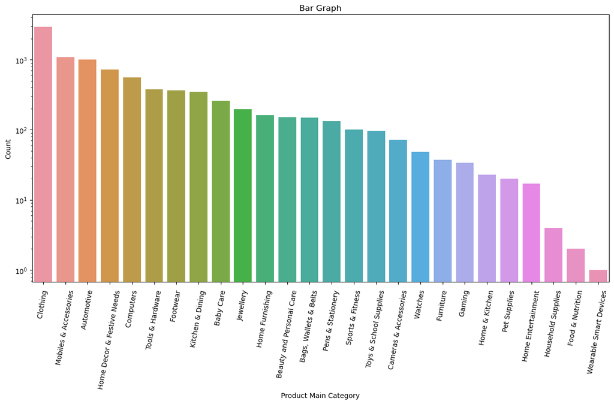

```python
plt.figure(figsize=(15,7))
plt.title('Bar Graph')
sns.countplot(data = df,x ='product_main_category', order = df['product_main_category'].value_counts().index)
plt.xticks(rotation=80)
plt.xlabel('Product Main Category')
plt.ylabel('Count')
plt.yscale('log');
```

### Ans 4 b)

#### Maximum 2 products ordered from 'product_main_category' are below:

```python
df.groupby('product_main_category')['Customer_uniq_id'].count().sort_values(ascending=False).head(2)
```

```
product_main_category
Clothing                  2943
Mobiles & Accessories     1084
Name: Customer_uniq_id, dtype: int64
```

#### Clothing and Mobiles & Accessories are the maximum products ordered

#### Minimum 2 products ordered from 'product_main_category' are below:

```python
df.groupby('product_main_category')['Customer_uniq_id'].count().sort_values(ascending=False).tail(2)
```

```
product_main_category
Food & Nutrition           2
Wearable Smart Devices     1
Name: Customer_uniq_id, dtype: int64
```

#### Food & Nutrition and Wearable Smart Devices are the minimum products ordered

### Ans 4 c)

#### Below is the code of top 5 product_main_category(s) in descending order

```python
df.groupby('product_main_category')['Customer_uniq_id'].count().sort_values(ascending=False)
```

```
product_main_category
Clothing                       2943
Mobiles & Accessories          1084
Automotive                     1001
Home Decor & Festive Needs      727
Computers                       558
                               ...
Pet Supplies                     20
Home Entertainment               17
Household Supplies                4
Food & Nutrition                  2
Wearable Smart Devices            1
Name: Customer_uniq_id, Length: 26, dtype: int64
```

In E-commerce, both the retailers (here brands) and the company have to make profit to sustain in the business. The E-Commerce company has the following rule for computing their own revenue:

#### (i) 25% on the orders having final price (discounted price) greater than 600

#### (ii) 15% on the orders having final price (discounted price) greater than 350 but less than or equal to 600

#### (iii) 10% on the orders having final price (discounted price) greater than 100 but less than or equal to 350

#### (iv) Otherwise, 5% on the final price (discounted price) </font>

## Q 5. Find the Total Revenue generated by the E-Commerce company over all orders placed. (6 marks)

#### Hint: Calculate revenue of E-commerce company using the conditions mentioned above and then do the total (sum) of all to get total Revenue.

### Ans 5

#### As mentioned above there are 4 conditions so we will create 4 seperate columns based on column 'discounted price'

```python
df.loc[df['discounted_price'] > 600, 'new_25'] = df['discounted_price']*0.25 + df['discounted_price']
df.loc[(df['discounted_price'] > 350) & (df['discounted_price'] <=600), 'new_15'] = df['discounted_price']*0.15 + df['discounted_price']
df.loc[(df['discounted_price'] > 100) & (df['discounted_price'] <=350), 'new_10'] = df['discounted_price']*0.1 + df['discounted_price']
df.loc[(df['discounted_price'] > 0) & (df['discounted_price'] <=100), 'new_0_to_100'] = df['discounted_price']*0.05 + df['discounted_price']
```

```python
df.describe()
```

|  | retail_price | discounted_price | product_rating | new_25 | new_15 | new_10 | new_0_to_100 |
| --- | --- | --- | --- | --- | --- | --- | --- |
| count | 8906.000000 | 8906.000000 | 8906.000000 | 3963.000000 | 2701.000000 | 2242.000000 | 0.0 |
| mean | 1969.965304 | 1093.698518 | 3.066596 | 2476.453129 | 559.773676 | 281.816860 | NaN |
| std | 3341.314408 | 2433.776099 | 1.413313 | 4306.760783 | 88.654824 | 72.001395 | NaN |
| min | 115.000000 | 109.000000 | 1.000000 | 761.250000 | 403.650000 | 119.900000 | NaN |
| 25% | 730.000000 | 350.000000 | 2.000000 | 1123.750000 | 460.000000 | 218.900000 | NaN |
| 50% | 1195.000000 | 599.000000 | 3.000000 | 1687.500000 | 573.850000 | 295.900000 | NaN |
| 75% | 2199.000000 | 1199.000000 | 4.000000 | 2123.750000 | 631.350000 | 330.000000 | NaN |
| max | 116292.000000 | 116292.000000 | 5.000000 | 145365.000000 | 690.000000 | 385.000000 | NaN |

#### As we can see some NA values, we will check the count of NA values

```python
df.isnull().sum()
```

```
Customer_uniq_id             0
Region                       0
Order_Date                   0
Expected_Delivery_Date       0
Delivered_Date               0
                          ...
description                  0
new_25                    4943
new_15                    6205
new_10                    6664
new_0_to_100              8906
Length: 21, dtype: int64
```

#### In order to calculate the total price based on the 4 conditions. We have replace the NA values with 0.

```python
df.fillna(0,inplace=True)
```

```python
df.describe()
```

|  | retail_price | discounted_price | product_rating | new_25 | new_15 | new_10 | new_0_to_100 |
| --- | --- | --- | --- | --- | --- | --- | --- |
| count | 8906.000000 | 8906.000000 | 8906.000000 | 8906.000000 | 8906.000000 | 8906.000000 | 8906.0 |
| mean | 1969.965304 | 1093.698518 | 3.066596 | 1101.974371 | 169.767426 | 70.944689 | 0.0 |
| std | 3341.314408 | 2433.776099 | 1.413313 | 3125.259063 | 261.917640 | 127.540495 | 0.0 |
| min | 115.000000 | 109.000000 | 1.000000 | 0.000000 | 0.000000 | 0.000000 | 0.0 |
| 25% | 730.000000 | 350.000000 | 2.000000 | 0.000000 | 0.000000 | 0.000000 | 0.0 |
| 50% | 1195.000000 | 599.000000 | 3.000000 | 0.000000 | 0.000000 | 0.000000 | 0.0 |
| 75% | 2199.000000 | 1199.000000 | 4.000000 | 1498.750000 | 458.850000 | 125.400000 | 0.0 |
| max | 116292.000000 | 116292.000000 | 5.000000 | 145365.000000 | 690.000000 | 385.000000 | 0.0 |

#### Since there are no more NA values, we can now create a column 'total_price' and add the 4 columns which we created.

```python
df['total_price'] = df['new_25'] + df['new_15'] + df['new_10'] + df['new_0_to_100']
```

```python
df.describe()
```

|  | retail_price | discounted_price | product_rating | new_25 | new_15 | new_10 | new_0_to_100 | total_price |
| --- | --- | --- | --- | --- | --- | --- | --- | --- |
| count | 8906.000000 | 8906.000000 | 8906.000000 | 8906.000000 | 8906.000000 | 8906.000000 | 8906.0 | 8906.000000 |
| mean | 1969.965304 | 1093.698518 | 3.066596 | 1101.974371 | 169.767426 | 70.944689 | 0.0 | 1342.686487 |
| std | 3341.314408 | 2433.776099 | 1.413313 | 3125.259063 | 261.917640 | 127.540495 | 0.0 | 3049.171035 |
| min | 115.000000 | 109.000000 | 1.000000 | 0.000000 | 0.000000 | 0.000000 | 0.0 | 119.900000 |
| 25% | 730.000000 | 350.000000 | 2.000000 | 0.000000 | 0.000000 | 0.000000 | 0.0 | 385.000000 |
| 50% | 1195.000000 | 599.000000 | 3.000000 | 0.000000 | 0.000000 | 0.000000 | 0.0 | 688.850000 |
| 75% | 2199.000000 | 1199.000000 | 4.000000 | 1498.750000 | 458.850000 | 125.400000 | 0.0 | 1498.750000 |
| max | 116292.000000 | 116292.000000 | 5.000000 | 145365.000000 | 690.000000 | 385.000000 | 0.0 | 145365.000000 |

#### Calculating the sum of column 'total_price'

```python
print('The total Revenue generated by the E-Commerce company after applying the above 4 condition is Rs',df['total_price'].sum() ,sep='')
```

```
The total Revenue generated by the E-Commerce company after applying the above 4 condition is Rs11957965.85
```

Now you need to find the revenue for each retailer (Brand)

## Q6.Calculate the total BrandRevenue and list the top 10 Brand having maximum revenue in descending order (6 marks)

#### Hint: Total BrandRevenue is BrandRevenue which is generated after all the deductions. Also, BrandRevenue is different from the E-Commerce company's revenue.

#### Brand Revenue is the discounted price minus the Revenue (generated using the conditions given above Q5)

### Ans 6

#### Creating the column 'BrandRevenue' by subtracting column 'discounted_price' from column 'total_price'

```python
df['BrandRevenue'] = df['total_price'] - df['discounted_price']
df.describe()
```

|  | retail_price | discounted_price | product_rating | new_25 | new_15 | new_10 | new_0_to_100 | total_price | BrandRevenue |
| --- | --- | --- | --- | --- | --- | --- | --- | --- | --- |
| count | 8906.000000 | 8906.000000 | 8906.000000 | 8906.000000 | 8906.000000 | 8906.000000 | 8906.0 | 8906.000000 | 8906.000000 |
| mean | 1969.965304 | 1093.698518 | 3.066596 | 1101.974371 | 169.767426 | 70.944689 | 0.0 | 1342.686487 | 248.987969 |
| std | 3341.314408 | 2433.776099 | 1.413313 | 3125.259063 | 261.917640 | 127.540495 | 0.0 | 3049.171035 | 615.711543 |
| min | 115.000000 | 109.000000 | 1.000000 | 0.000000 | 0.000000 | 0.000000 | 0.0 | 119.900000 | 10.900000 |
| 25% | 730.000000 | 350.000000 | 2.000000 | 0.000000 | 0.000000 | 0.000000 | 0.0 | 385.000000 | 35.000000 |
| 50% | 1195.000000 | 599.000000 | 3.000000 | 0.000000 | 0.000000 | 0.000000 | 0.0 | 688.850000 | 89.850000 |
| 75% | 2199.000000 | 1199.000000 | 4.000000 | 1498.750000 | 458.850000 | 125.400000 | 0.0 | 1498.750000 | 299.750000 |
| max | 116292.000000 | 116292.000000 | 5.000000 | 145365.000000 | 690.000000 | 385.000000 | 0.0 | 145365.000000 | 29073.000000 |

#### The total BrandRevenue is mentioned below

```python
print('The total BrandRevenue is Rs',df['BrandRevenue'].sum() , sep='')
```

```
The total BrandRevenue is Rs2217486.85
```

#### The top 10 BrandRevenue having maximum revenue is mentioned below

```python
a = df.groupby('Brand')['BrandRevenue'].sum().sort_values(ascending=False).head(10).index.tolist()
```

```python
print('The top 10 Brand having maximum revenue in descending order are',a)
```

```
The top 10 Brand having maximum revenue in descending order are ['ALLURE AUTO', 'GAGA', 'DAILYOBJECTS', 'SLIM', 'DIVINITI', 'ENTHOPIA', 'ASUS', 'SPRINGWEL', 'AUDEZE', 'REGULAR']
```

Let us now investigate multiple features for each product to determine any pattern.

## Q 7. Compare prices for each product.

## a) Draw boxplots of retail_price & discounted_price. (3 marks)

## b) Are there any outliers? (Yes/No) (1mark)

## c) Create a scatterplot of retail_price (x-axis) and discounted_price (y-axis) (3 marks)

### Ans 7 a)

#### Boxplot for Retail Price

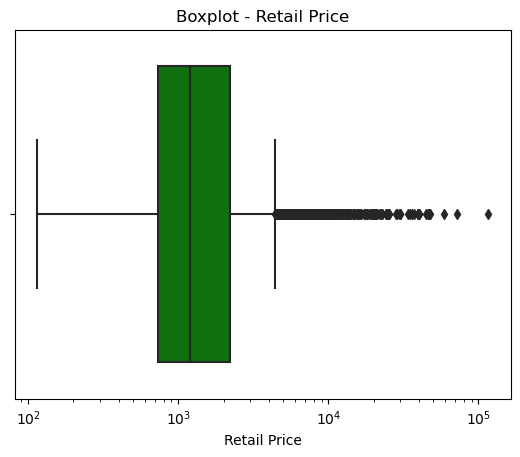

```python
plt.title('Boxplot - Retail Price')
plt.xlabel('Horsepower')
sns.boxplot(data=df,x='retail_price' , color='green')
plt.xlabel('Retail Price')
plt.xscale('log');
```

#### Boxplot for Discounted Price

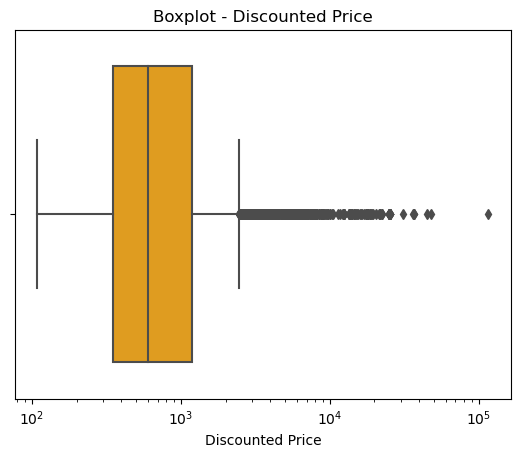

```python
plt.title('Boxplot - Discounted Price')
plt.xlabel('Horsepower')
sns.boxplot(data=df,x='discounted_price' , color='orange')
plt.xlabel('Discounted Price')
plt.xscale('log');
```

### Ans 7 b)

#### From the above boxplots we can see that there are multiple outliers in both the columns 'retail_price' and 'discounted_price'

### Ans 7 c)

#### The scatterplot of retail_price (x-axis) and discounted_price (y-axis) is shown below

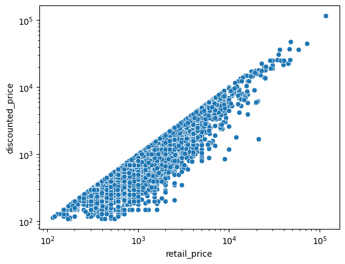

```python
sns.scatterplot(data=df, x = 'retail_price', y ='discounted_price')
plt.xscale('log')
plt.yscale('log');
```

The next steps will enable to study brand-level information.

## Q 8. Create a new dataframe to include the Brand specific information as stated:

## i. total number of orders placed per Brand

## ii. total retail_price per Brand

## iii. total discounted_price per Brand, and

## iv. total BrandRevenue generated per Brand.

## Also, draw a pairplot using these four features. (6 marks)

### Ans 8

#### There are 4 conditions in the question. We will calculate it sequentially as shown below

#### First we need to create data series 'brand_count' to calculate total number of orders placed per Brand

```python
brand_count = df.groupby('Brand')['Customer_uniq_id'].count().sort_values(ascending=False)
brand_count
```

```
Brand
ALLURE AUTO       469
REGULAR           300
SLIM              267
THELOSTPUPPY      250
BLACK             147
                 ...
JAYENTERPRISE       1
JAYCOKNIT           1
JAYANTI SAREES      1
JAPDAN              1
 TARKAN             1
Name: Customer_uniq_id, Length: 2484, dtype: int64
```

#### Second we need to create data series 'brand_retail_price_total' to calculate total retail_price per Brand

```python
brand_retail_price_total = df.groupby('Brand')['retail_price'].sum().sort_values(ascending=False)
brand_retail_price_total
```

```
Brand
ALLURE AUTO         1973880
GAGA                 571909
SLIM                 533724
THELOSTPUPPY         531750
REGULAR              304545
                     ...
MAX                     149
KHADI                   140
MEDIMIX                 129
OSWAL                   120
HM INTERNATIONAL        120
Name: retail_price, Length: 2484, dtype: int64
```

#### Third we need to create data series 'brand_discounted_price_total' to calculate total discounted_price per Brand

```python
brand_discounted_price_total = df.groupby('Brand')['discounted_price'].sum().sort_values(ascending=False)
brand_discounted_price_total
```

```
Brand
ALLURE AUTO          664619
GAGA                 316520
SLIM                 272177
DAILYOBJECTS         242640
DIVINITI             190820
                      ...
DR. THAPAR'S            120
LAADLI BOUTIQUE         110
LAADLI BOUITIQUE        110
OBS                     110
DIGITAL MARKETING       110
Name: discounted_price, Length: 2484, dtype: int64
```

#### Fourth we need to create data series 'brand_BrandRevenue_total' to calculate total BrandRevenue generated per Brand

```python
brand_BrandRevenue_total = df.groupby('Brand')['BrandRevenue'].sum().sort_values(ascending=False)
brand_BrandRevenue_total
```

```
Brand
ALLURE AUTO          166154.75
GAGA                  79130.00
DAILYOBJECTS          60660.00
SLIM                  60114.40
DIVINITI              47705.00
                       ...
DR. THAPAR'S             12.00
LAADLI BOUITIQUE         11.00
LAADLI BOUTIQUE          11.00
DIGITAL MARKETING        11.00
OBS                      11.00
Name: BrandRevenue, Length: 2484, dtype: float64
```

#### Now we will combine all the above 4 data series in one data frame 'brand'

```python
brands = pd.DataFrame({'brand_count':brand_count,'brand_retail' : brand_retail_price_total,
                       'brand_discounted' : brand_discounted_price_total , 'brand_brandrevenue':brand_BrandRevenue_total})
```

```python
brands.describe()
```

|  | brand_count | brand_retail | brand_discounted | brand_brandrevenue |
| --- | --- | --- | --- | --- |
| count | 2484.000000 | 2.484000e+03 | 2484.000000 | 2484.000000 |
| mean | 3.585346 | 7.063008e+03 | 3921.287842 | 892.708072 |
| std | 15.599639 | 4.706971e+04 | 19518.250853 | 4748.883761 |
| min | 1.000000 | 1.200000e+02 | 110.000000 | 11.000000 |
| 25% | 1.000000 | 8.990000e+02 | 494.750000 | 67.350000 |
| 50% | 1.000000 | 1.739500e+03 | 998.000000 | 208.000000 |
| 75% | 2.000000 | 3.999000e+03 | 2395.250000 | 531.050000 |
| max | 469.000000 | 1.973880e+06 | 664619.000000 | 166154.750000 |

#### Below is the Pair plot including all the 4 data series

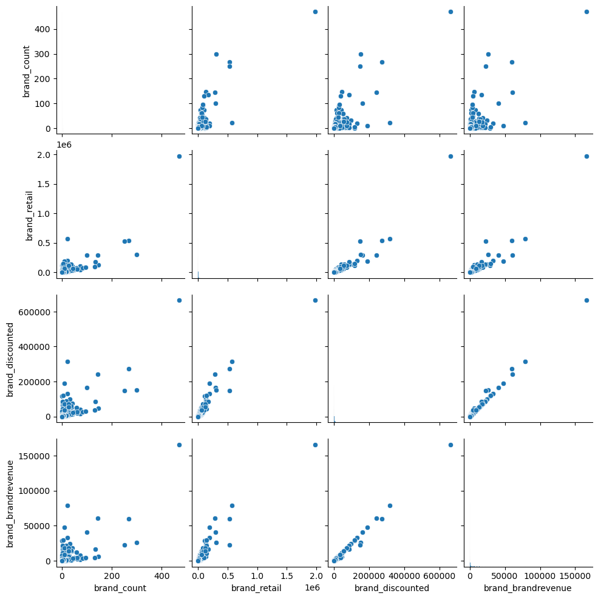

```python
sns.pairplot(data=brands[['brand_count','brand_retail','brand_discounted','brand_brandrevenue']])
```

The E-Commerce company operate in multiple regions. It is important to understand its performance in each region.

## Q 9.Compare performance regionwise

## a) Draw a lineplot for the monthly Revenue of E-Commerce Company for each region separately. (4 marks)

## b) Identify the best and the worst performing months for each region. (2 marks)

#### Note: Only those days with actual orders(Order_Date) placed are present in the dataset. Assuming there were no orders on other days. Also, show Month and Year on x-axis.

### Ans 9 a)

#### In the question it is asked to draw month-wise graph based on column 'Order_Date', So we have to extract month, year and day

```python
df.info()
```

[output not shown]

#### As we can see the data type of column 'Order_Date' is Object we have to convert it into datetime format

```python
df['Order_Date'] = pd.to_datetime(df['Order_Date'] , dayfirst=True)
```

```python
df.info()
```

```
<class 'pandas.core.frame.DataFrame'>
RangeIndex: 8906 entries, 0 to 8905
Data columns (total 23 columns):
 #   Column                      Non-Null Count  Dtype
---  ------                      --------------  -----
 0   Customer_uniq_id            8906 non-null   object
 1   Region                      8906 non-null   object
 2   Order_Date                  8906 non-null   datetime64[ns]
 3   Expected_Delivery_Date      8906 non-null   object
 4   Delivered_Date              8906 non-null   object
 5   product_name                8906 non-null   object
 6   product_main_category       8906 non-null   object
 7   product_subcategory         8906 non-null   object
 8   product_category_filter     8906 non-null   object
 9   product_category_subfilter  8906 non-null   object
 10  product_unique ID           8906 non-null   object
 11  retail_price                8906 non-null   int64
 12  discounted_price            8906 non-null   int64
 13  product_rating              8906 non-null   float64
 14  Brand                       8906 non-null   object
 15  product_specifications      8906 non-null   object
 16  description                 8906 non-null   object
 17  new_25                      8906 non-null   float64
 18  new_15                      8906 non-null   float64
 19  new_10                      8906 non-null   float64
 20  new_0_to_100                8906 non-null   float64
 21  total_price                 8906 non-null   float64
 22  BrandRevenue                8906 non-null   float64
dtypes: datetime64[ns](1), float64(7), int64(2), object(13)
memory usage: 1.6+ MB
```

#### Now column 'Order_Date' is converted to datetime format now we can extract day, month and year

```python
# Extracting year

df['year'] = df['Order_Date'].dt.year
df.head(2)
```

|  | Customer_uniq_id | Region | Order_Date | Expected_Delivery_Date | Delivered_Date | product_name | product_main_category | product_subcategory | product_category_filter | product_category_subfilter | ... | Brand | product_specifications | description | new_25 | new_15 | new_10 | new_0_to_100 | total_price | BrandRevenue | year |
| --- | --- | --- | --- | --- | --- | --- | --- | --- | --- | --- | --- | --- | --- | --- | --- | --- | --- | --- | --- | --- | --- |
| 0 | e71017e224688489edfe856f2308806d | East | 2021-10-24 | 25-10-2021 | 25-10-2021 | Indcrown Net Embroidered Semi-stitched Lehenga... | Clothing | Women's Clothing | Ethnic Wear | Fabric | ... | INDCROWN | {"product_specification"=>[{"key"=>"Fabric", "... | Key Features of Indcrown Net Embroidered Semi-... | 873.75 | 0.0 | 0.0 | 0.0 | 873.75 | 174.75 | 2021 |
| 1 | 6286847ee2da18f587503db49511c539 | East | 2021-10-24 | 25-10-2021 | 25-10-2021 | Shopmania Music Band A5 Notebook Spiral Bound | Pens & Stationery | Diaries & Notebooks | Notebooks | Designer | ... | SHOPMANIA | {"product_specification"=>[{"key"=>"Ruling", "... | Specifications of Shopmania Music Band A5 Note... | 0.00 | 0.0 | 302.5 | 0.0 | 302.50 | 27.50 | 2021 |

2 rows × 24 columns

```python
df['year'].unique()
```

```
array([2021, 2020], dtype=int64)
```

#### There are 2 year 2020 and 2021

```python
# Extracting month

df['order_month'] = df['Order_Date'].dt.month
df.head(3)
```

|  | Customer_uniq_id | Region | Order_Date | Expected_Delivery_Date | Delivered_Date | product_name | product_main_category | product_subcategory | product_category_filter | product_category_subfilter | ... | product_specifications | description | new_25 | new_15 | new_10 | new_0_to_100 | total_price | BrandRevenue | year | order_month |
| --- | --- | --- | --- | --- | --- | --- | --- | --- | --- | --- | --- | --- | --- | --- | --- | --- | --- | --- | --- | --- | --- |
| 0 | e71017e224688489edfe856f2308806d | East | 2021-10-24 | 25-10-2021 | 25-10-2021 | Indcrown Net Embroidered Semi-stitched Lehenga... | Clothing | Women's Clothing | Ethnic Wear | Fabric | ... | {"product_specification"=>[{"key"=>"Fabric", "... | Key Features of Indcrown Net Embroidered Semi-... | 873.75 | 0.0 | 0.0 | 0.0 | 873.75 | 174.75 | 2021 | 10 |
| 1 | 6286847ee2da18f587503db49511c539 | East | 2021-10-24 | 25-10-2021 | 25-10-2021 | Shopmania Music Band A5 Notebook Spiral Bound | Pens & Stationery | Diaries & Notebooks | Notebooks | Designer | ... | {"product_specification"=>[{"key"=>"Ruling", "... | Specifications of Shopmania Music Band A5 Note... | 0.00 | 0.0 | 302.5 | 0.0 | 302.50 | 27.50 | 2021 | 10 |
| 2 | 0686fec9b70e5039583a38119ca0c835 | West | 2021-10-24 | 25-10-2021 | 25-10-2021 | Shopmania Music Band A5 Notebook Spiral Bound | Pens & Stationery | Diaries & Notebooks | Notebooks | Designer | ... | {"product_specification"=>[{"key"=>"Ruling", "... | Specifications of Shopmania Music Band A5 Note... | 0.00 | 0.0 | 302.5 | 0.0 | 302.50 | 27.50 | 2021 | 10 |

3 rows × 25 columns

```python
df['order_month'].nunique()
```

```
11
```

```python
df['order_month'].unique()
```

```
array([10,  9,  8, 12,  7,  6,  5,  3,  4,  1,  2], dtype=int64)
```

#### There are 11 months, month 'November' is missing

```python
# Extracting day

df['order_day'] = df['Order_Date'].dt.day
df.head(3)
```

|  | Customer_uniq_id | Region | Order_Date | Expected_Delivery_Date | Delivered_Date | product_name | product_main_category | product_subcategory | product_category_filter | product_category_subfilter | ... | description | new_25 | new_15 | new_10 | new_0_to_100 | total_price | BrandRevenue | year | order_month | order_day |
| --- | --- | --- | --- | --- | --- | --- | --- | --- | --- | --- | --- | --- | --- | --- | --- | --- | --- | --- | --- | --- | --- |
| 0 | e71017e224688489edfe856f2308806d | East | 2021-10-24 | 25-10-2021 | 25-10-2021 | Indcrown Net Embroidered Semi-stitched Lehenga... | Clothing | Women's Clothing | Ethnic Wear | Fabric | ... | Key Features of Indcrown Net Embroidered Semi-... | 873.75 | 0.0 | 0.0 | 0.0 | 873.75 | 174.75 | 2021 | 10 | 24 |
| 1 | 6286847ee2da18f587503db49511c539 | East | 2021-10-24 | 25-10-2021 | 25-10-2021 | Shopmania Music Band A5 Notebook Spiral Bound | Pens & Stationery | Diaries & Notebooks | Notebooks | Designer | ... | Specifications of Shopmania Music Band A5 Note... | 0.00 | 0.0 | 302.5 | 0.0 | 302.50 | 27.50 | 2021 | 10 | 24 |
| 2 | 0686fec9b70e5039583a38119ca0c835 | West | 2021-10-24 | 25-10-2021 | 25-10-2021 | Shopmania Music Band A5 Notebook Spiral Bound | Pens & Stationery | Diaries & Notebooks | Notebooks | Designer | ... | Specifications of Shopmania Music Band A5 Note... | 0.00 | 0.0 | 302.5 | 0.0 | 302.50 | 27.50 | 2021 | 10 | 24 |

3 rows × 26 columns

```python
df['Region'].unique()
```

```
array(['East ', 'West', 'North', 'South'], dtype=object)
```

#### Since there are 4 regions we will now create 4 data frames for all 4 regions

```python
# West Region

region_west = df[df['Region'] == 'West']
region_west.head(3)
```

|  | Customer_uniq_id | Region | Order_Date | Expected_Delivery_Date | Delivered_Date | product_name | product_main_category | product_subcategory | product_category_filter | product_category_subfilter | ... | description | new_25 | new_15 | new_10 | new_0_to_100 | total_price | BrandRevenue | year | order_month | order_day |
| --- | --- | --- | --- | --- | --- | --- | --- | --- | --- | --- | --- | --- | --- | --- | --- | --- | --- | --- | --- | --- | --- |
| 2 | 0686fec9b70e5039583a38119ca0c835 | West | 2021-10-24 | 25-10-2021 | 25-10-2021 | Shopmania Music Band A5 Notebook Spiral Bound | Pens & Stationery | Diaries & Notebooks | Notebooks | Designer | ... | Specifications of Shopmania Music Band A5 Note... | 0.00 | 0.0 | 302.5 | 0.0 | 302.50 | 27.50 | 2021 | 10 | 24 |
| 3 | ea2406dc597bee2abb6b867fa668501f | West | 2021-10-24 | 25-10-2021 | 25-10-2021 | Tiara Diaries 2016-2017 Designer LA Kaarta "TA... | Pens & Stationery | Diaries & Notebooks | Notebooks | Designer | ... | Specifications of Tiara Diaries 2016-2017 Desi... | 1046.25 | 0.0 | 0.0 | 0.0 | 1046.25 | 209.25 | 2021 | 10 | 24 |
| 9 | 547b6585272473ae006bcfbdb47b6ae0 | West | 2021-08-26 | 27-08-2021 | 27-08-2021 | Nuride Canvas Shoes | Footwear | Women's Footwear | Casual Shoes | Canvas | ... | Key Features of Nuride Canvas Shoes Material: ... | 1686.25 | 0.0 | 0.0 | 0.0 | 1686.25 | 337.25 | 2021 | 8 | 26 |

3 rows × 26 columns

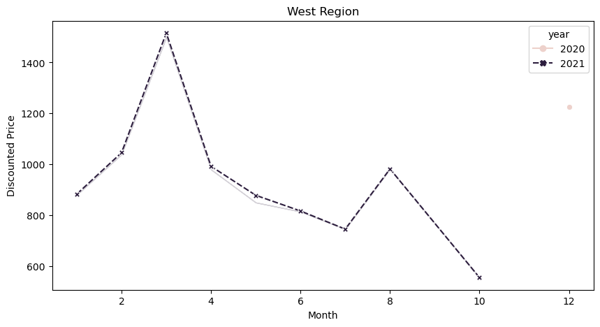

```python
plt.figure(figsize=(10,5))
plt.xlabel('Month')
plt.ylabel('Discounted Price')
sns.lineplot(data=region_west, x='order_month' , y='discounted_price' , hue='year' , style ='year' , ci=False , markers=True)
plt.title('West Region');
```

```python
# East Region - In the data set there is a extra space in column 'Region' for 'East '

region_east = df[df['Region'] == 'East ']
region_east.head(3)
```

|  | Customer_uniq_id | Region | Order_Date | Expected_Delivery_Date | Delivered_Date | product_name | product_main_category | product_subcategory | product_category_filter | product_category_subfilter | ... | description | new_25 | new_15 | new_10 | new_0_to_100 | total_price | BrandRevenue | year | order_month | order_day |
| --- | --- | --- | --- | --- | --- | --- | --- | --- | --- | --- | --- | --- | --- | --- | --- | --- | --- | --- | --- | --- | --- |
| 0 | e71017e224688489edfe856f2308806d | East | 2021-10-24 | 25-10-2021 | 25-10-2021 | Indcrown Net Embroidered Semi-stitched Lehenga... | Clothing | Women's Clothing | Ethnic Wear | Fabric | ... | Key Features of Indcrown Net Embroidered Semi-... | 873.75 | 0.0 | 0.0 | 0.0 | 873.75 | 174.75 | 2021 | 10 | 24 |
| 1 | 6286847ee2da18f587503db49511c539 | East | 2021-10-24 | 25-10-2021 | 25-10-2021 | Shopmania Music Band A5 Notebook Spiral Bound | Pens & Stationery | Diaries & Notebooks | Notebooks | Designer | ... | Specifications of Shopmania Music Band A5 Note... | 0.00 | 0.0 | 302.5 | 0.0 | 302.50 | 27.50 | 2021 | 10 | 24 |
| 4 | 5935ed077915347dc695744df68c565c | East | 2021-09-03 | 04-09-2021 | 04-09-2021 | KAJCI Embroidered Women's Waistcoat | Clothing | Women's Clothing | Formal Wear | Waistcoats | ... | Specifications of KAJCI Embroidered Women's Wa... | 873.75 | 0.0 | 0.0 | 0.0 | 873.75 | 174.75 | 2021 | 9 | 3 |

3 rows × 26 columns

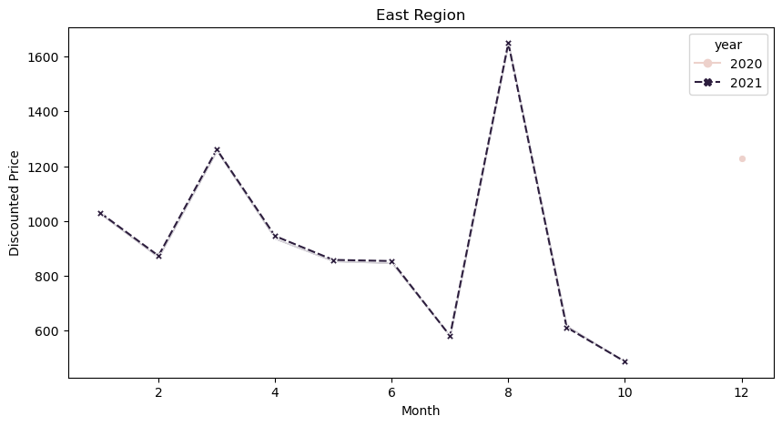

```python
plt.figure(figsize=(10,5))
plt.xlabel('Month')
plt.ylabel('Discounted Price')
sns.lineplot(data=region_east, x='order_month' , y='discounted_price' , hue='year' , style ='year' , ci=False , markers=True)
plt.title('East Region');
```

```python
region_south = df[df['Region'] == 'South']
region_south.head(3)
```

|  | Customer_uniq_id | Region | Order_Date | Expected_Delivery_Date | Delivered_Date | product_name | product_main_category | product_subcategory | product_category_filter | product_category_subfilter | ... | description | new_25 | new_15 | new_10 | new_0_to_100 | total_price | BrandRevenue | year | order_month | order_day |
| --- | --- | --- | --- | --- | --- | --- | --- | --- | --- | --- | --- | --- | --- | --- | --- | --- | --- | --- | --- | --- | --- |
| 477 | 4422b30c32ce553e1044576c7fc1357a | South | 2020-12-01 | 04-12-2020 | 04-12-2020 | 3a AUTOCARE Car Mat Toyota Innova | Automotive | Accessories & Spare parts | Car Interior & Exterior | Car Interior | ... | Buy 3a AUTOCARE Car Mat Toyota Innova for Rs.2... | 3437.50 | 0.0 | 0.0 | 0.0 | 3437.50 | 687.50 | 2020 | 12 | 1 |
| 482 | 942659b62d524e8731ca1f776586e352 | South | 2020-12-01 | 04-12-2020 | 04-12-2020 | 3a Autocare Beat Car Mat Chevrolet Beat | Automotive | Accessories & Spare parts | Car Interior & Exterior | Car Interior | ... | 3a Autocare Beat Car Mat Chevrolet Beat (Beige... | 1825.00 | 0.0 | 0.0 | 0.0 | 1825.00 | 365.00 | 2020 | 12 | 1 |
| 529 | 742496b60ce5597a6daa836dbacff5a2 | South | 2021-06-10 | 13-06-2021 | 13-06-2021 | Accessoreez Headlight LED Bulb for TATA PRIMA | Automotive | Car & Bike Accessories | Car & Bike Lighting | Car Lighting | ... | Key Features of Accessoreez Headlight LED Bulb... | 1186.25 | 0.0 | 0.0 | 0.0 | 1186.25 | 237.25 | 2021 | 6 | 10 |

3 rows × 26 columns

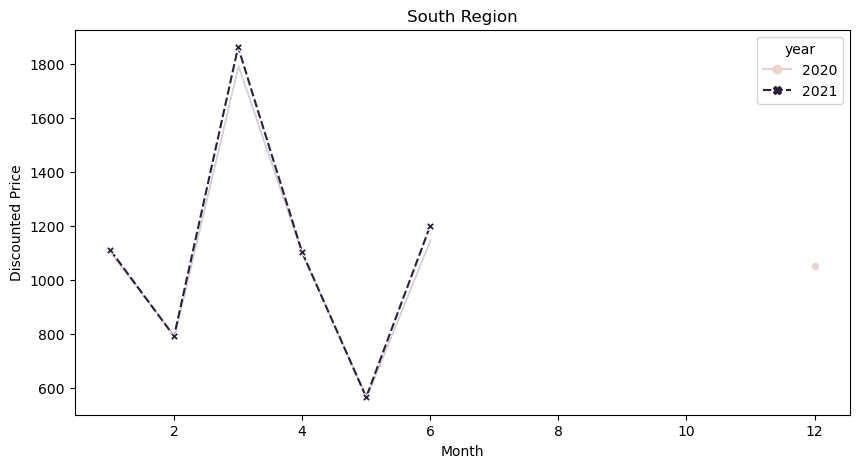

```python
plt.figure(figsize=(10,5))
plt.xlabel('Month')
plt.ylabel('Discounted Price')
sns.lineplot(data=region_south, x='order_month' , y='discounted_price' , hue='year' , style ='year' , ci=False , markers=True)
plt.title('South Region');
```

```python
region_north = df[df['Region'] == 'North']
region_north.head(3)
```

|  | Customer_uniq_id | Region | Order_Date | Expected_Delivery_Date | Delivered_Date | product_name | product_main_category | product_subcategory | product_category_filter | product_category_subfilter | ... | description | new_25 | new_15 | new_10 | new_0_to_100 | total_price | BrandRevenue | year | order_month | order_day |
| --- | --- | --- | --- | --- | --- | --- | --- | --- | --- | --- | --- | --- | --- | --- | --- | --- | --- | --- | --- | --- | --- |
| 10 | f6ae9e271a1d4469b4f41124e001e1cc | North | 2021-08-26 | 27-08-2021 | 27-08-2021 | OM SHIVAKRITI Square wall Clock Showpiece - ... | Home Decor & Festive Needs | Showpiece | Gramophones | OM SHIVAKRITI Gramophones | ... | Key Features of OM SHIVAKRITI Square wall Cloc... | 1873.75 | 0.0 | 0.0 | 0.0 | 1873.75 | 374.75 | 2021 | 8 | 26 |
| 16 | 7a7e587d3344885bdb8c77f8b7679483 | North | 2021-07-30 | 31-07-2021 | 01-08-2021 | Vermello Men Casual Brown Genuine Leather Belt | Bags, Wallets & Belts | Belts | Vermello Belts | Vermello Men Casual Brown Genuine Leather Bel... | ... | Specifications of Vermello Men Casual Brown Ge... | 993.75 | 0.0 | 0.0 | 0.0 | 993.75 | 198.75 | 2021 | 7 | 30 |
| 17 | c497e4250ea07a8a87efa8fda01ae6e0 | North | 2021-07-30 | 31-07-2021 | 01-08-2021 | HRS CLUB BOY Thigh Pads | Sports & Fitness | Team Sports | Cricket | Cricket Pads | ... | HRS CLUB BOY Thigh Pads (WHITE, RIGHT-HANDED) ... | 0.00 | 0.0 | 275.0 | 0.0 | 275.00 | 25.00 | 2021 | 7 | 30 |

3 rows × 26 columns

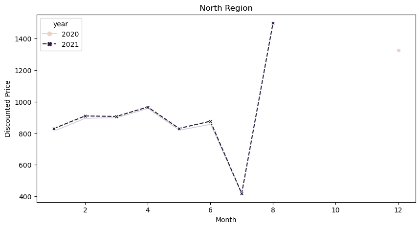

```python
plt.figure(figsize=(10,5))
plt.xlabel('Month')
plt.ylabel('Discounted Price')
sns.lineplot(data=region_north, x='order_month' , y='discounted_price' , hue='year' , style ='year' , ci=False , markers=True)
plt.title('North Region');
```

#### Graphs of all 4 regions are shown above and we can see that in year 2020 orders are placed only in Dec month

### Ans 9 b)

#### Best and the worst performing months for each region are shown below:

```python
# West Region - Best

region_west.groupby(['Region','order_month'])['discounted_price'].sum().sort_values(ascending=False).head(1)
```

```
Region  order_month
West    12             1306500
Name: discounted_price, dtype: int64
```

```python
# West Region - Worst

region_west.groupby(['Region','order_month'])['discounted_price'].sum().sort_values(ascending=False).tail(1)
```

```
Region  order_month
West    10             1112
Name: discounted_price, dtype: int64
```

#### In West Region best month is Dec and worst month is Oct.

```python
# East Region - Best

region_east.groupby(['Region','order_month'])['discounted_price'].sum().sort_values(ascending=False).head(1)
```

```
Region  order_month
East    12             1568994
Name: discounted_price, dtype: int64
```

```python
# East Region - Worst

region_east.groupby(['Region','order_month'])['discounted_price'].sum().sort_values(ascending=False).tail(1)
```

```
Region  order_month
East    10             974
Name: discounted_price, dtype: int64
```

#### In East Region best month is Dec and worst month is Oct.

```python
# South Region - Best

region_south.groupby(['Region','order_month'])['discounted_price'].sum().sort_values(ascending=False).head(1)
```

```
Region  order_month
South   12             422076
Name: discounted_price, dtype: int64
```

```python
# South Region - Worst

region_south.groupby(['Region','order_month'])['discounted_price'].sum().sort_values(ascending=False).tail(1)
```

```
Region  order_month
South   5              19253
Name: discounted_price, dtype: int64
```

#### In South Region best month is Dec and worst month is May.

```python
# North Region - Best

region_north.groupby(['Region','order_month'])['discounted_price'].sum().sort_values(ascending=False).head(1)
```

```
Region  order_month
North   12             828217
Name: discounted_price, dtype: int64
```

```python
# North Region - Worst

region_north.groupby(['Region','order_month'])['discounted_price'].sum().sort_values(ascending=False).tail(1)
```

```
Region  order_month
North   8              1499
Name: discounted_price, dtype: int64
```

#### In North Region best month is Dec and worst month is Aug.

### From the above information we can say that Dec is the highest performing month or Best month in terms of revenue for discounted price.

# BY - Ayush Kumar

Congratulations! You have learnt how to approach a complex data and extract information out of it.